# Detección de los co-retweeters

Los co-retweetes son perfiles que coinciden al difundir los mismos mensajes. Que dos personas no coordinadas coincidan al retuitear los mismos mensajes más de n veces es poco probable. Pero que esto ocurra con cientos de perfiles es aún más difícil.

El principal problema es ajustar los parámetros tanto en la detección de los usuarios co-retweeters como en el filtrado por análisis de red.

### Parámetros utilizados

Los parámetros utilizados dependerán de cada dataset y su ajuste es empírico.

Los parámetros usados en este caso son:

- **Nombre del dataset** = PSOE: Nombre del directorio dónde se encuentra el dataset
- **prefijo** = PSOE: Nombre del prefijo del dataset
- **min_retweets_msg** = 50: descarta los mensajes con el número de RTs menor que este parámetro. Este valor no es muy restrictivo y puede hacer el dataset más fácil de procesar sin perder la detección de los co-retweeters.
- **max_retweets_msg** 10000: descarta los mensajes con el número de RTs mayor que este parámetro. Si se disminuye este valor para descartar tweets virales, el tiempo de ejecución disminuye drásticamente. No obstante, puede alterar el resultado al generar un contador de co-retweets mucho menor o no detectar a los que se coinciden solo en tweets virales.
- **min_shared_tweets** = 50: Este parámetro pone el umbral de número de coincidencias al retuitear para considerar a dos perfiles co-retweeters. Antes de procesar descarta a los usuarios que han retuiteado menos que este valor, ya que no entrarían en el grupo de co-retweeters. Cuanto más alto sea este valor, menor será el número de co-retweeters.
- **percen_co_retweeters** = 20: es el porcentaje de usuarios con más co-retweeters. Este parámetro descarta a los perfiles cuyo número de co-retwweters está por debajo este porcentaje. Sirve para aligerar el tiempo de ejecución de los grafos y delimitar a los co-retweeters más coincidentes. En datasets con poca cocurrencia, se aconseja que el porcentaje sea 100.

## KPIs del dataset PSOE

KPIs: Original vs Filtrado

| tipo | n_tweets | n_retweeters | n_RTs | n_beneficiarios |
| --- | --- | --- | --- | --- |
| Original | 2.977 | 22.239 | 435.898 | 1 |
| Filtrado | 2.182 | 1.405 | 321.913 | 1 |

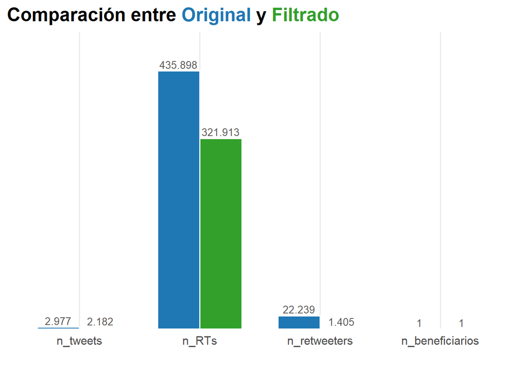

## Análisis de los co-retweeters

### Comunidades

Agrupación de los usuarios con conexiones más frecuentes.

[figure not shown]

### Distribución

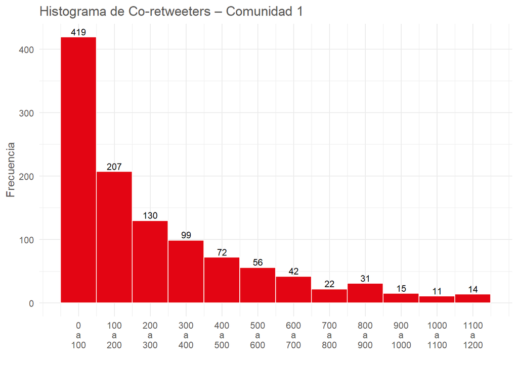

### Co-retweeters vs. retweets

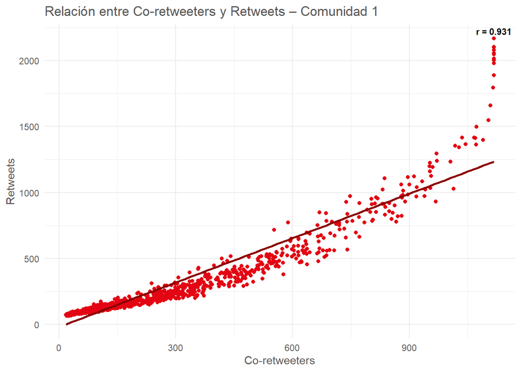

### Top co-retweeters

Los 25 usuarios más relevantes ordenados decrecientemente por su número de co-retweeters y retweets

#### Comunidad 1

Co-retweets destacados de la comunidad 1 en el dataset de PSOE

| community | Profile | Co-retweeters | Retweets | Eigen |
| --- | --- | --- | --- | --- |
| 1 | @937908Mcm | 1.117 | 2.170 | 1.0000000 |
| 1 | @ernestortegalh | 1.117 | 2.104 | 0.9791458 |
| 1 | @juanmapspvbetxi | 1.117 | 2.104 | 0.9813874 |
| 1 | @RAFAELLEALSALAZ | 1.117 | 2.102 | 0.9738031 |
| 1 | @cmaeso68 | 1.117 | 2.080 | 0.9695025 |
| 1 | @CeutaPlataforma | 1.117 | 2.056 | 0.9528885 |
| 1 | @vegaparrilla | 1.117 | 2.048 | 0.9560439 |
| 1 | @DRZRZ | 1.117 | 2.015 | 0.9323621 |
| 1 | @jocesbol2 | 1.117 | 2.003 | 0.9437611 |
| 1 | @Miguel_A_Guti | 1.117 | 1.980 | 0.9323231 |
| 1 | @Lilialex2015 | 1.117 | 1.890 | 0.8942080 |
| 1 | @KilianCD | 1.115 | 1.796 | 0.8548492 |
| 1 | @bedmar_pere | 1.108 | 1.661 | 0.7969051 |
| 1 | @jesus43703354 | 1.103 | 1.549 | 0.7561302 |
| 1 | @solgarvives | 1.089 | 1.399 | 0.6898071 |
| 1 | @RubenEtayo | 1.073 | 1.497 | 0.7159249 |
| 1 | @Alcoyanista27 | 1.072 | 1.363 | 0.6825548 |
| 1 | @TaniaCrespo3 | 1.070 | 1.412 | 0.6897868 |
| 1 | @KVASpain | 1.067 | 1.416 | 0.6997243 |
| 1 | @Margari38357275 | 1.045 | 1.367 | 0.6769847 |
| 1 | @MariaCarme5612 | 1.036 | 1.417 | 0.6848931 |
| 1 | @anap1958 | 1.028 | 1.343 | 0.6515803 |
| 1 | @MARIAJE77 | 1.018 | 1.355 | 0.6578788 |
| 1 | @ali_dabeh | 1.014 | 1.027 | 0.5550774 |
| 1 | @Ser9gio_GR | 1.006 | 1.235 | 0.6136701 |

### Top de parejas de co-retweeters

Las 25 parejas con más coincidencia en sus retweets. Es decir, ambos han coincidido en retweetear el número de tweets de la columna weight.

Muestra visualmente las conexiones del 5% de los parejas más relacionadas, mediante un algoritmo que atrae a los más coincidentes.

#### Comunidad 1

Parejas de co-retweets destacados de la comunidad 1 en el dataset de PSOE

| community | Perfil_1 | Perfil_2 | weight |
| --- | --- | --- | --- |
| 1 | @937908Mcm | @juanmapspvbetxi | 2.098 |
| 1 | @937908Mcm | @ernestortegalh | 2.095 |
| 1 | @937908Mcm | @RAFAELLEALSALAZ | 2.091 |
| 1 | @937908Mcm | @cmaeso68 | 2.074 |
| 1 | @CeutaPlataforma | @RAFAELLEALSALAZ | 2.056 |
| 1 | @ernestortegalh | @juanmapspvbetxi | 2.051 |
| 1 | @937908Mcm | @CeutaPlataforma | 2.045 |
| 1 | @937908Mcm | @vegaparrilla | 2.039 |
| 1 | @RAFAELLEALSALAZ | @juanmapspvbetxi | 2.033 |
| 1 | @RAFAELLEALSALAZ | @ernestortegalh | 2.030 |
| 1 | @cmaeso68 | @juanmapspvbetxi | 2.027 |
| 1 | @cmaeso68 | @ernestortegalh | 2.022 |
| 1 | @RAFAELLEALSALAZ | @cmaeso68 | 2.006 |
| 1 | @937908Mcm | @DRZRZ | 2.005 |
| 1 | @937908Mcm | @jocesbol2 | 1.998 |
| 1 | @CeutaPlataforma | @ernestortegalh | 1.988 |
| 1 | @CeutaPlataforma | @juanmapspvbetxi | 1.988 |
| 1 | @RAFAELLEALSALAZ | @vegaparrilla | 1.982 |
| 1 | @ernestortegalh | @vegaparrilla | 1.979 |
| 1 | @juanmapspvbetxi | @vegaparrilla | 1.979 |
| 1 | @937908Mcm | @Miguel_A_Guti | 1.973 |
| 1 | @jocesbol2 | @juanmapspvbetxi | 1.964 |
| 1 | @CeutaPlataforma | @cmaeso68 | 1.960 |
| 1 | @cmaeso68 | @vegaparrilla | 1.960 |
| 1 | @ernestortegalh | @jocesbol2 | 1.953 |

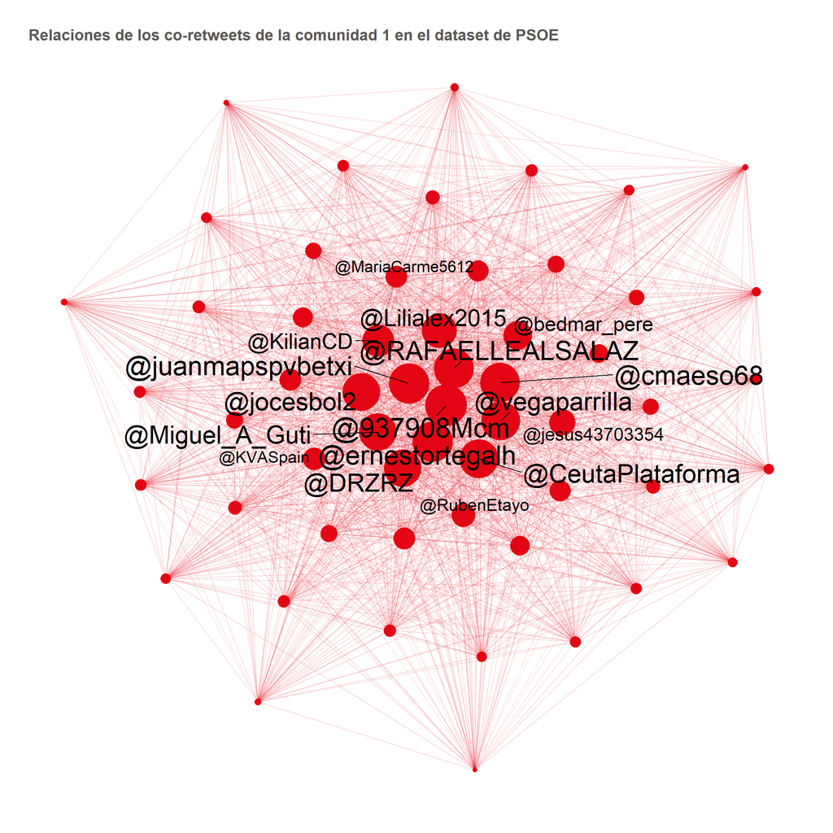

## Beneficiarios

Para cada comunidad se genera un grafo de las relaciones entre los co-retweeters y los retuiteados, a los que se denomina como **“beneficiarios”**

El layout aplicado es **Force Atlas-2** con los siguientes parámetros:

- iterations = 300
- gravity = 2
- linlog = TRUE

Para generar un grafo más ligero y disminuir el tiempo de visualización, se han seleccionado los perfiles más coincidentes. Se ha aplicado el porcentaje de selección del 20 % con más co-retweeters.

En caso de haber solo un beneficiario, por ejemplo el análisis de un perfil, no se muestra el grafo al no aportar información relevante.

Para generar un etiquetado claro de los nodos, solo se muestran aquellos que se encuentran en el grupo del 30% con más grado. Se utiliza la opción de **repel** para evitar que se solapen, en la medida de los posible.

El color de los nodos **beneficiarios** es siempre naranja y el de los co-retweeters el de su comunidad.

Las aristas son del color del nodo origen, es decir de los co-retweeeters.

### Comunidad 1

Beneficiarios destacados de la comunidad 1 en el dataset de PSOE

| Profile | Retweets en comunidad | Retweets en total | community |
| --- | --- | --- | --- |
| @PSOE | 305.451 | 321.913 | 1 |

Solo hay un beneficiario, no se genera el grafo por no ser necesario